# Red Wine Quality Exploration by Cora Ou

# Bivariate Analysis

### Talk about some of the relationships you observed in this part of the investigation. How did the feature(s) of interest vary with other features in the dataset?

Fixed acidity and quality do not have much correlaiton and citric acid and quality are slightly positively correlated. But Volatile acidity and quality have strong negative correlation. Acidity(fixed and volatile) and citric acid are strongly correlated. But fixed acidity and volatile acidity are only slightly correlated.

### Did you observe any interesting relationships between the other features (not the main feature(s) of interest)?

Acidity(fixed and volatile) and citric acid have strong correlation with pH, while SO2 and sulphates do not. And SO2(free and total) are not related to pH.

### What was the strongest relationship you found?

Positive: fixed.acidity and citric.acid Negative: fixed.acidity and pH

# Multivariate Plots Section

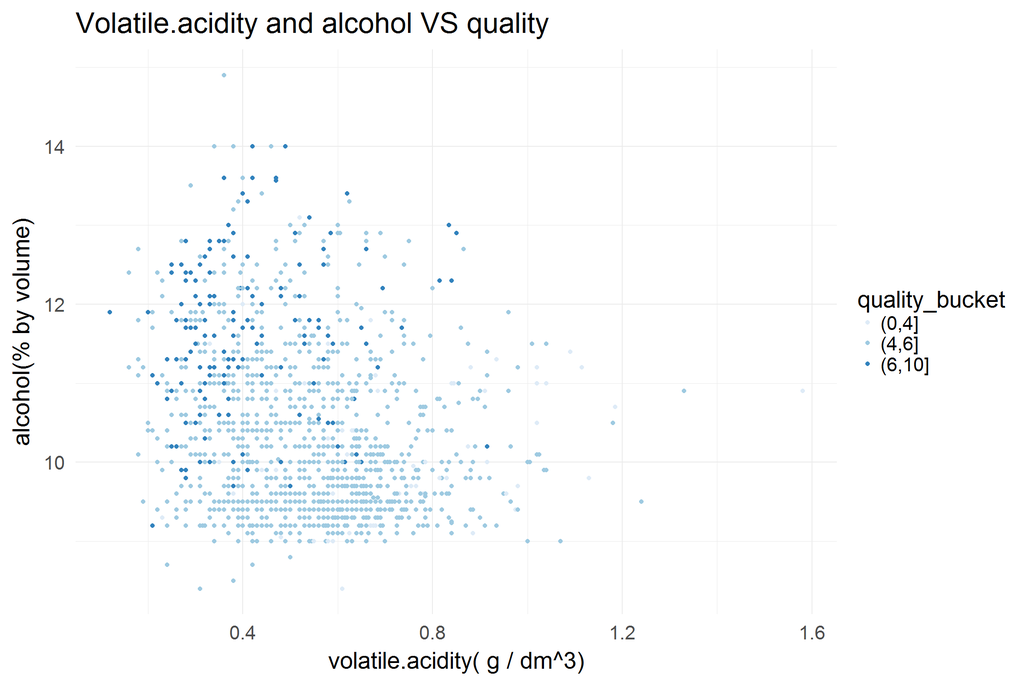

Best wines concentrate when volatile.acidity is below 0.4 and alcohol is about 12.

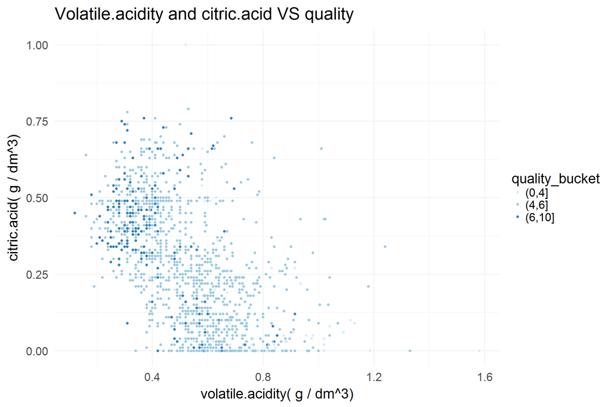

I’d like to say best wines concentrate when citric.acid is 0.5 and volatile.acidity is 0.4, but there are also many mediocre wines.

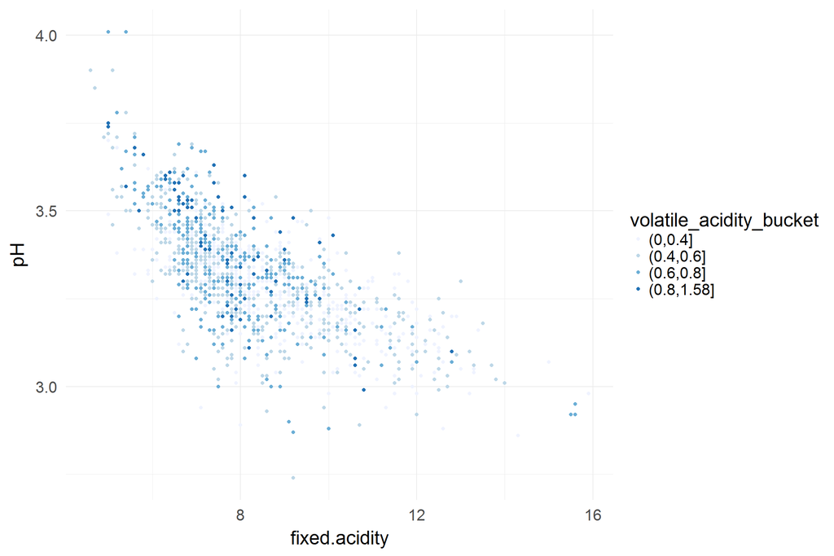

It seems the pH of red wine decreases when fixed.acidity increases and volatile.acidity decreases.

# Multivariate Analysis

### Talk about some of the relationships you observed in this part of the investigation. Were there features that strengthened each other in terms of looking at your feature(s) of interest?

Best wines concentrate when volatile.acidity is below 0.4 and alcohol is about 12. As for pH, I also discover that pH of red wine decreases when fixed.acidity increases and volatile.acidity decreases.

### Were there any interesting or surprising interactions between features?

Though I can find where best wines concentrate in the alcohol and volatile.acidity plot, it is hard to find when it comes to volatile.acidity and citric.acid. Perhaps it has something to do with how correlated the variables are with quality.

# Final Plots and Summary

### Plot One

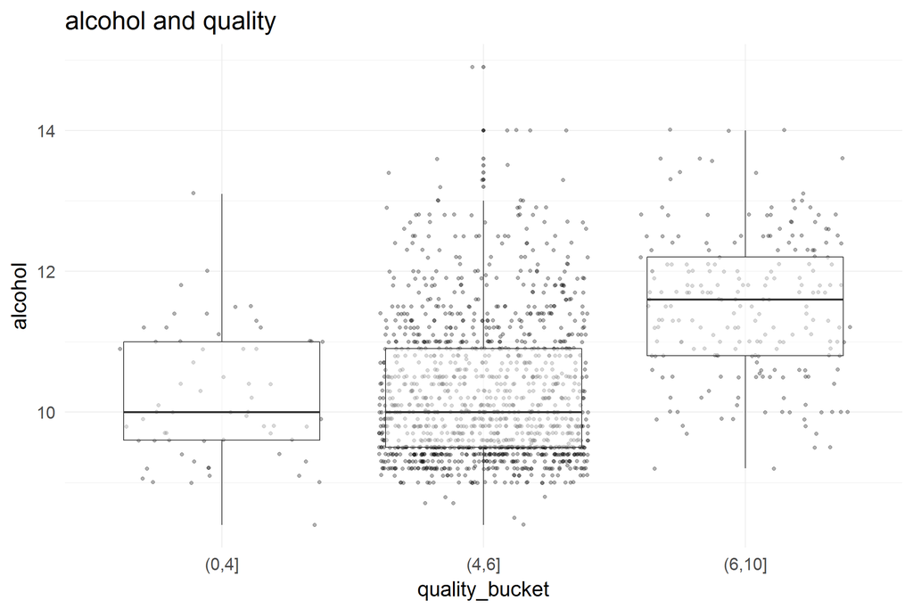

### Description One

It seems most best wines have alcohol of below 12%.

### Plot Two

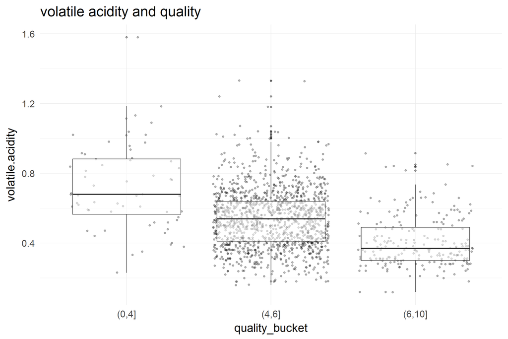

### Description Two

Best wines have only 0.4g/dm^3 of volatile acidity.

### Plot Three

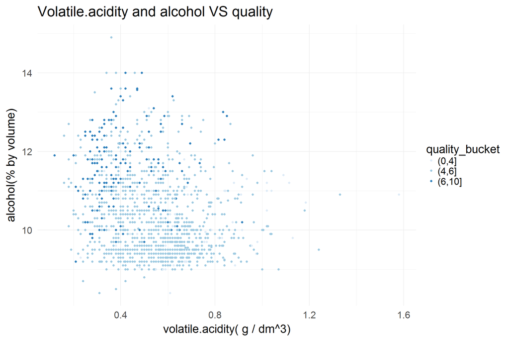

## It seems best wines constitute volatile acidity of lower than 0.4g/dm^3 and more than 10% alcohol. Mediocre wines concentrate when volatile acidity is between 0.4 and 0.8 and alcohol is about 10%

# Reflection

The data set contains information on almost 1599 wine sampels across 12 features. In initial phase, I investigated individual variables(univariate analysis). Then I explored quality of wine accross variables and the relationship between those variables. (bivariate analysis and multivariate analysis)

The analysis performed on the sample dataset can be summarised as below: It is discovered that alcohol and volatile.acidity are significantly correlated with quality. So among the 12 features, these two properties can serve as predictors of the quality of red wine. Also, as expected, pH is related to acidity(fixed and volatile) and acid. But surprisingly, it is not correlated with SO2.

Some of the learnings from the analysis were as follows:

We can’t take the relationship between variables as granted. When I was investigating the relations between quality and other variables, I discovered that acidity and acid are related to pH and to quality. So I thought pH and quality must also have correlations. But after I plotted, I found that there was no correlation between these two variables. Also, I suspected SO2 was significantly correlated to pH. But actually it was the other way around. So everytime we investigate some kinds of relationships, we’d better not rely too much on our intutions. Instead, we should draw plots or calculate their coefficient.

A limitation of the current analysis is that the quality of the red wines were rated only by three experts, which lacked authority and credibility. Furthermore, unlike carat of the diamonds dataset whose coefficient with price is about 1, the strongest predictor of quality of this dataset has a coefficient of only 0.49. So perhaps there are other more reliable variables that can predict the quality of red wine.

So I’d like to suggest that people who take charge of the data collection of this data set invite more experts to rate the quality of these red wines. Also, other variables like the quantity of the Tartaric acid which is the most important in wine according to wiki pedia, can be included in the data set.